# Stabilization Facility sample visualization

Rohan

This is a visualization representing my engagement with UNDP Libya Stabilization Facility. For the purpose of this exercise and general sharing, the names of individual projects (activities) have been generalized and financial figures have been altered from the actual data.

## Importing libraries

```r
library(tidyverse)
library(reshape2)
library(viridis)
library(scales)
```

## Importing csv file

```r
sfl <- read.csv("tracker.csv")
```

## Setting theme

```r
theme_set(theme_minimal())
```

## Changing data types

```r
sfl$Contract.Signing <- as.Date(sfl$Contract.Signing, "%m/%d/%Y")
sfl$Start.Date <- as.Date(sfl$Start.Date, "%m/%d/%Y")
sfl$Actual.completion.date <- as.Date(sfl$Actual.completion.date, "%m/%d/%Y")
```

## Progress status chart

### Refactoring status variable

```r
sfl$Overall.Status <-
        factor(sfl$Overall.Status, levels = c("Completed","Underway", "With Procurement", "In Development"))
```

### Plot progress status using bar plot

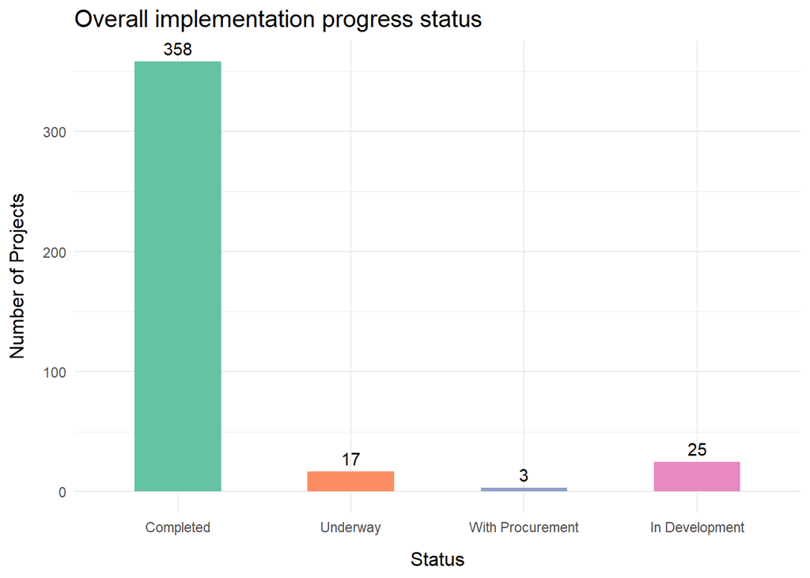

```r
ggplot(sfl, aes(x=Overall.Status, fill=Overall.Status)) +
        geom_bar(width = 0.5)+
        geom_text(aes(label=stat(count)), stat = "count", vjust=-0.5)+
        scale_fill_brewer(type="qual", palette = 7, guide=NULL)+
        labs(title = "Overall implementation progress status", x = "Status", y="Number of Projects")+
        theme(plot.title = element_text(size = 15),
              axis.title = element_text(size=12),
              axis.title.y = element_text(margin = margin(r=10)),
              axis.title.x = element_text(margin = margin(t=10)))
```

### Fund status

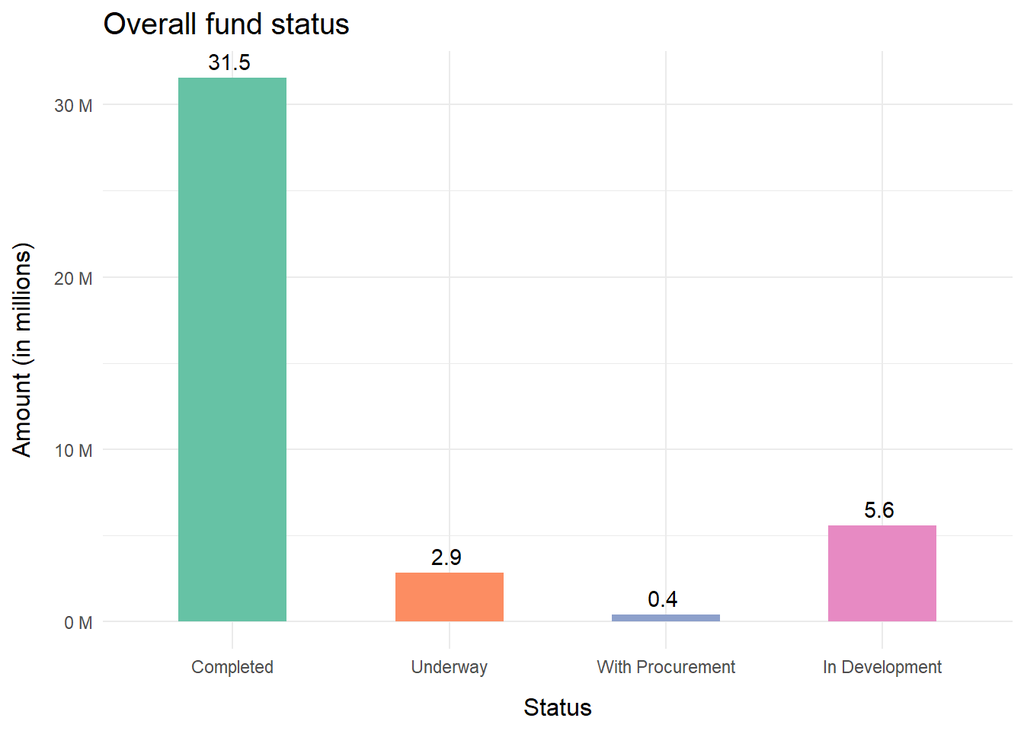

```r
ggplot(sfl, aes(x=Overall.Status, y=Amount, fill=Overall.Status)) +
        geom_col(width = 0.5)+
        scale_y_continuous(labels = unit_format(unit="M",scale = 1e-6))+
        stat_summary(fun = sum, geom = "text",
                     aes(label = scales::unit_format
                         (unit = "", scale = 1e-6)(..y..)), vjust = -0.5)+
        scale_fill_brewer(type="qual", palette = 7, guide=NULL)+
        labs(title = "Overall fund status", x="Status", y="Amount (in millions)") +
        theme(plot.title = element_text(size = 15),
              axis.title = element_text(size=12),
              axis.title.y = element_text(margin = margin(r=10)),
              axis.title.x = element_text(margin = margin(t=10)))
```

## Sector wise

### Numbers of activities per sector

#### Create a subset data for number of activities by sector

```r
sector_count <- count(sfl, Sector)
```

#### Plotting number of activities per sector

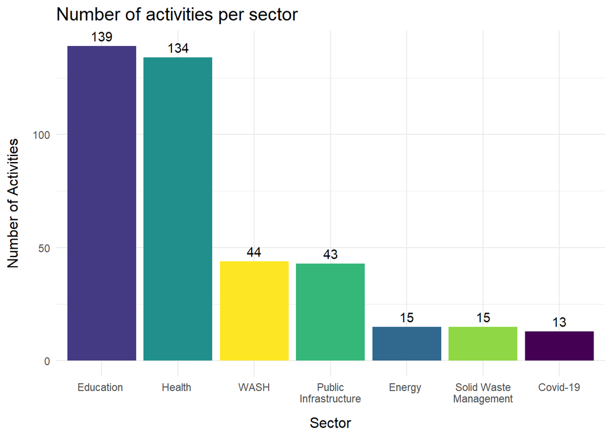

```r
ggplot(sector_count, aes(x=fct_reorder(Sector, n, .desc = TRUE), y=n, fill=Sector))+
        geom_col()+
        geom_text(aes(label=n, vjust=-0.5))+
        scale_fill_viridis_d(guide=NULL)+
        labs(title="Number of activities per sector",
             x="Sector",
             y="Number of Activities")+
        scale_x_discrete(labels = c("Public Infrastructure and Services" = "Public\nInfrastructure",
                                    "Solid Waste Management" = "Solid Waste\nManagement"))+
        theme(plot.title = element_text(size = 15),
              axis.title = element_text(size=12),
              axis.title.y = element_text(margin = margin(r=10)),
              axis.title.x = element_text(margin = margin(t=10)))
```

**Summary:** Compared to other sectors, education and health sectors have far more numbers of activities.

### Sector Wise amount distribution

#### Creating data subset for amount by sector

```r
sector_amount <- sfl %>%
        group_by(Sector) %>%
        summarise(total_amount = sum(Amount, na.rm = TRUE))
```

#### Plotting amount distribution by sector

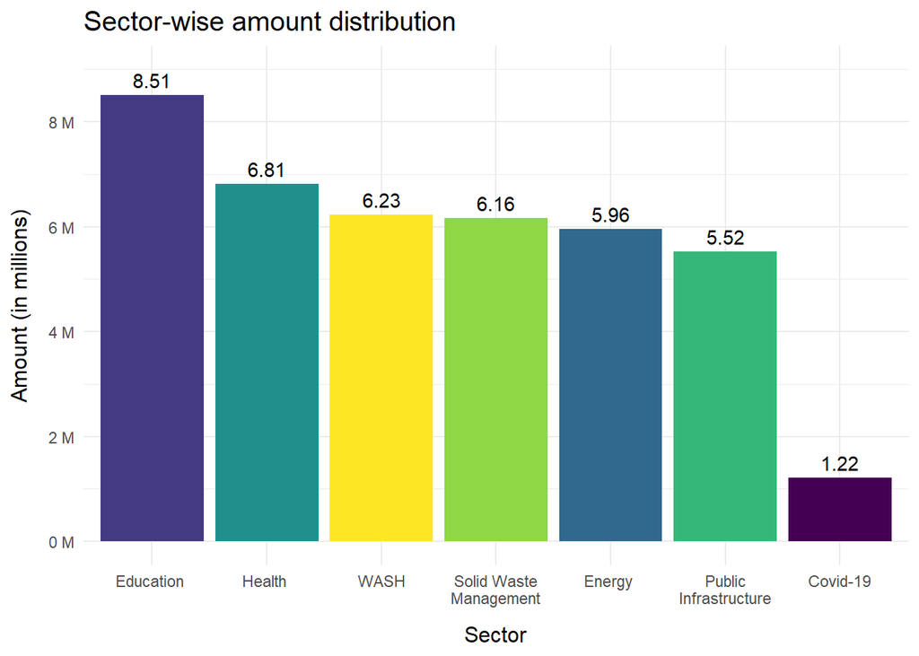

```r
ggplot(sector_amount, aes(x=fct_reorder(Sector, total_amount, .desc = TRUE), y=total_amount, fill=Sector))+
        geom_col()+
        geom_text(aes(label=sprintf("%.2f", total_amount/1e6), vjust=-0.5))+
        scale_fill_viridis_d(guide=NULL)+
        labs(title="Sector-wise amount distribution",
             x="Sector",
             y="Amount (in millions)")+
        scale_x_discrete(labels = c("Public Infrastructure and Services" = "Public\nInfrastructure",
                                    "Solid Waste Management" = "Solid Waste\nManagement"))+
        scale_y_continuous(limits = c(NA,9000000), n.breaks = 6, labels = scales::unit_format(unit = "M", scale = 1e-6)) +
        theme(plot.title = element_text(size = 15),
              axis.title = element_text(size=12),
              axis.title.y = element_text(margin = margin(r=10)),
              axis.title.x = element_text(margin = margin(t=10)))
```

**Summary:** Budget is highest for education sector but unlike numbers of activities, there isn’t a huge difference in budget distribution, apart from Covid-19 interventions.

#### Line Plot showing amount distribution by sector

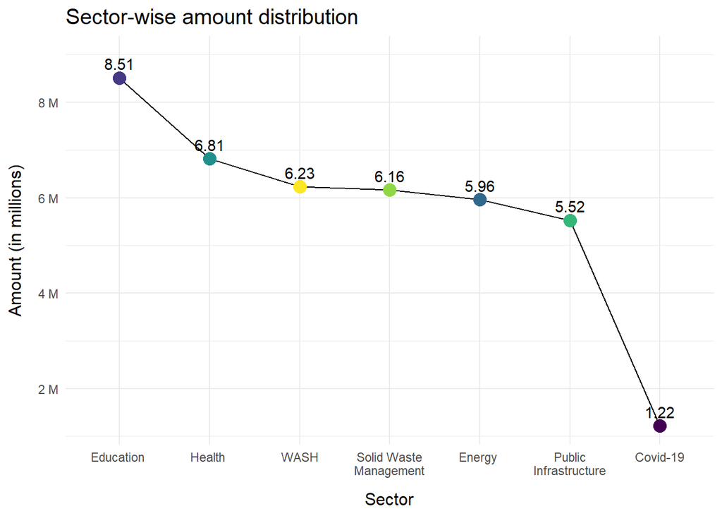

```r
ggplot(sector_amount, aes(x=fct_reorder(Sector, total_amount, .desc = TRUE), y=total_amount, group=1))+
        geom_line()+
        geom_point(aes(color=Sector),size=4)+
        geom_text(aes(label=sprintf("%.2f", total_amount/1e6), vjust=-0.7))+
        scale_x_discrete(labels = c("Public Infrastructure and Services" = "Public\nInfrastructure",
                                    "Solid Waste Management" = "Solid Waste\nManagement"))+
        scale_y_continuous(limits = c(NA, 9000000), n.breaks = 6, labels = scales::unit_format(unit = "M", scale = 1e-6)) +
        scale_color_viridis_d(guide=NULL)+
        labs(title="Sector-wise amount distribution",
             x="Sector",
             y="Amount (in millions)")+
        theme(plot.title = element_text(size = 15),
              axis.title = element_text(size=12),
              axis.title.y = element_text(margin = margin(r=10)),
              axis.title.x = element_text(margin = margin(t=10)))
```

### Distribution as per value of activities

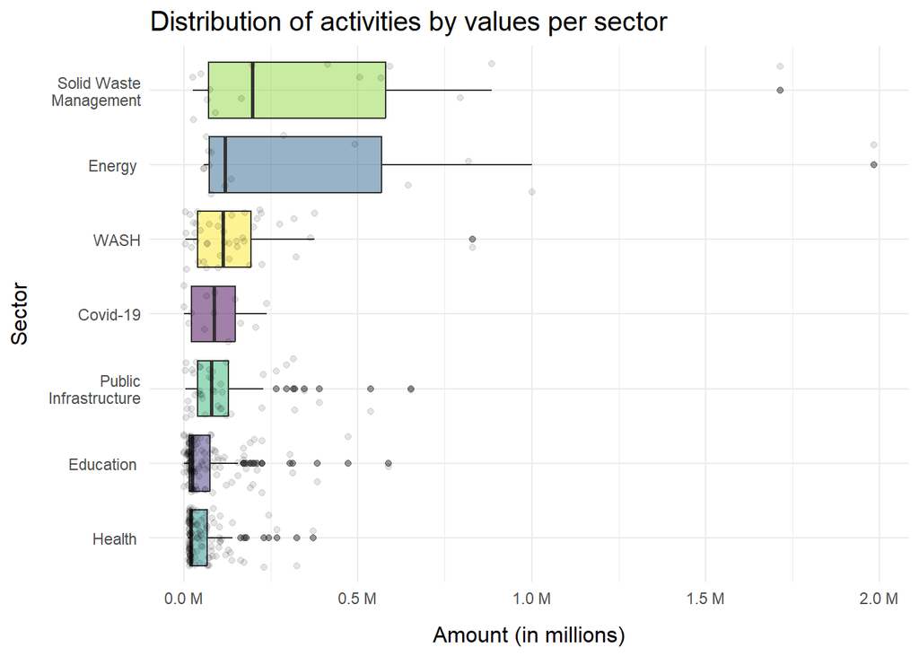

```r
ggplot(sfl, aes(y=fct_reorder(Sector, Amount, .fun = median, .na_rm = T), x=Amount)) +
        geom_boxplot(aes(fill=Sector), alpha=0.5) +
        geom_point(position = position_jitter(width = 0.2, seed = 1), alpha=0.1)+
        scale_fill_viridis_d(guide=NULL)+
        scale_y_discrete(labels = c("Public Infrastructure and Services" = "Public\nInfrastructure",
                                    "Solid Waste Management" = "Solid Waste\nManagement"))+
        scale_x_continuous(labels = unit_format(unit="M",scale = 1e-6))+
        labs(title = "Distribution of activities by values per sector ",
             x="Amount (in millions)",
             y="Sector") +
        theme(plot.title = element_text(size = 15),
              axis.title = element_text(size = 12),
              axis.title.y = element_text(margin = margin(r = 10)),
              axis.title.x = element_text(margin = margin(t = 10)))
```

**Summary:** Here we can see that in general, value of individual activities for health and education sectors are much less, and that of solid waste management and energy are higher.

## Implementation period

### Histrogram plot showing number of activities as per implementation duration

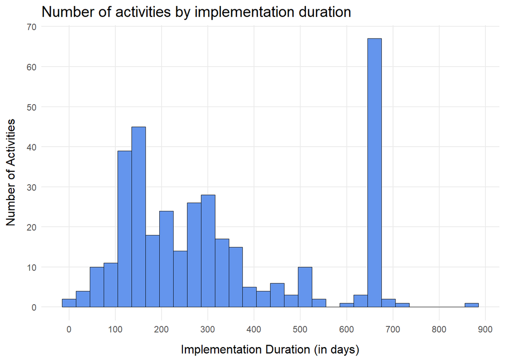

```r
ggplot(sfl, aes(x = Implementation_duration)) +
        geom_histogram(binwidth = 30, color="black",fill="cornflowerblue",linewidth=0.1) +
        labs(title = "Number of activities by implementation duration",
             x = "Implementation Duration (in days)",
             y = "Number of Activities") +
        scale_x_continuous(n.breaks = 10) +
        scale_y_continuous(n.breaks = 6) +
        theme(plot.title = element_text(size = 15),
              axis.title = element_text(size = 12),
              axis.title.y = element_text(margin = margin(r = 10)),
              axis.title.x = element_text(margin = margin(t = 10)),
              panel.grid.minor = element_blank())
```

## Activities contracted by year

### Creating a subset of data

```r
contract_year <- sfl %>%
        filter(!is.na(Contract.Signing)) %>%
        group_by(year(Contract.Signing)) %>%
        summarise(count = n()) %>%
        rename(year = `year(Contract.Signing)`)
```

### Creating a line plot to show number of contracts issued per year

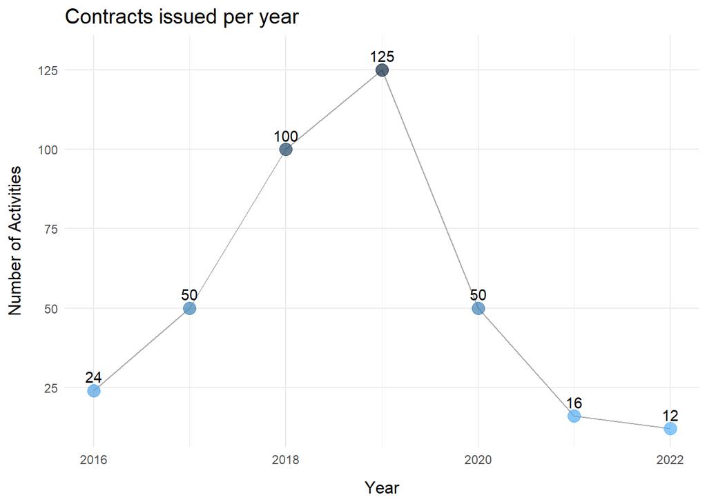

```r
ggplot(contract_year, aes(x=year, y=count))+
        geom_line(color="darkgrey") +
        geom_point(size=4, aes(color=count), alpha=.7) +
        geom_text(aes(label=count, vjust=-0.7)) +
        labs(title = "Contracts issued per year", x = "Year", y = "Number of Activities") +
        scale_color_gradient(high = "#132B43",
  low = "#56B1F7", guide = NULL)+
        scale_y_continuous(limits = c(NA,130), n.breaks = 6)+
        theme(plot.title = element_text(size = 15),
              axis.title = element_text(size = 12),
              axis.title.y = element_text(margin = margin(r = 10)),
              axis.title.x = element_text(margin = margin(t = 10)),
              panel.grid.minor.y = element_blank())
```

**Summary:** Contract issuance was in increasing trend until year 2019, where it was at it highest. The trend decreased starting from 2020, which was marred by pandemic. ***

## Activities completed by year

### Creating a subset of data

```r
complete_year <- sfl %>%
        filter(!is.na(Actual.completion.date)) %>%
        group_by(year(Actual.completion.date)) %>%
        summarise(count = n()) %>%
        rename(year = `year(Actual.completion.date)`)
```

### Creating a line plot to show number of activities completed per year

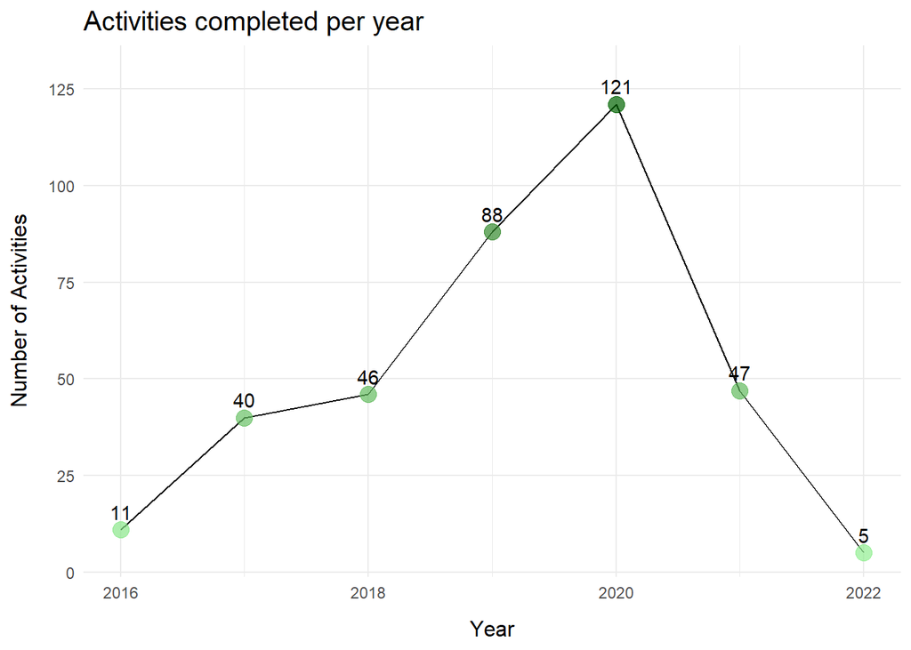

```r
ggplot(complete_year, aes(x=year, y=count)) +
        geom_line()+
        geom_point(size=4, aes(color=count), alpha=0.7)+
        geom_text(aes(label=count), vjust=-0.7) +
        labs(title = "Activities completed per year", x = "Year", y = "Number of Activities") +
        scale_color_gradient(high = "darkgreen",
  low = "lightgreen", guide = NULL)+
        scale_y_continuous(limits = c(NA,130), n.breaks = 6)+
        theme(plot.title = element_text(size = 15),
              axis.title = element_text(size = 12),
              axis.title.y = element_text(margin = margin(r = 10)),
              axis.title.x = element_text(margin = margin(t = 10)),
              panel.grid.minor.y = element_blank())
```

**Summary:** This shows alignment with contract issuance trend. One thing to note is that during pandemic also, the implementation was not affected that much. ***

## Location wise

### Number of activities

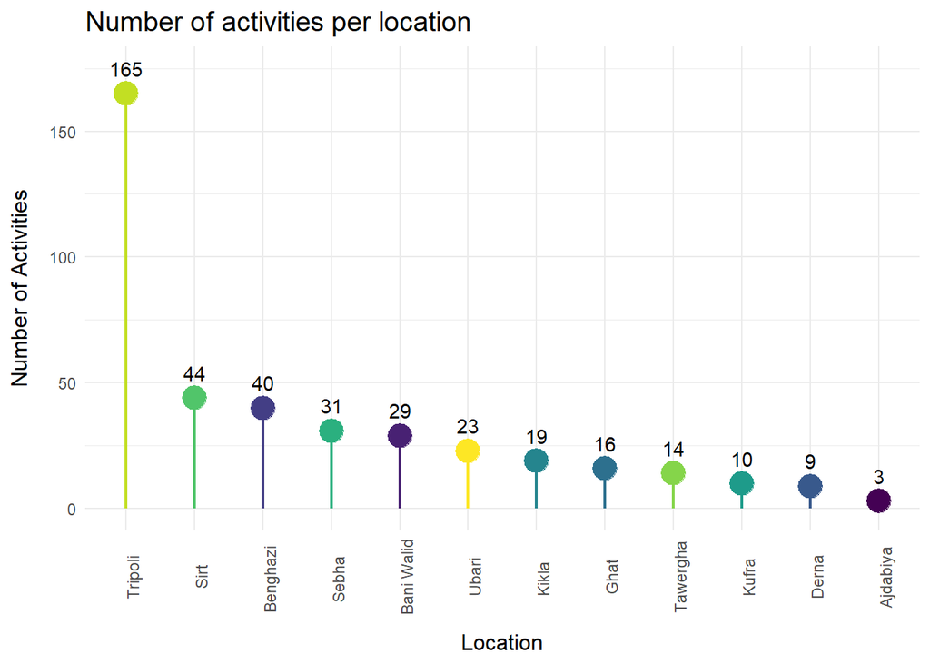

```r
ggplot(sfl, aes(x=fct_reorder(Location, Location, .fun = length, .desc = T, .na_rm = T), fill=Location))+
        geom_bar(width = 0.04)+
        geom_point(aes(color=Location), stat="count", size=6)+
        geom_text(aes(label=stat(count)), stat="count", color="black", nudge_y = 10)+
        scale_fill_viridis_d(guide=NULL)+
        scale_color_viridis_d(guide=NULL)+
        labs(title = "Number of activities per location",
             x="Location",
             y="Number of Activities")+
        theme(plot.title = element_text(size=15),
              axis.title = element_text(size=12),
              axis.title.y = element_text(margin = margin(r=10)),
              axis.title.x = element_text(margin = margin(t=10)),
              axis.text.x = element_text(angle=90))
```

**Summary:** Tripoli has far more number of activities. Here, chunk of education and health activities, which were relatively small in value, were also implemented.

### Amount distribution

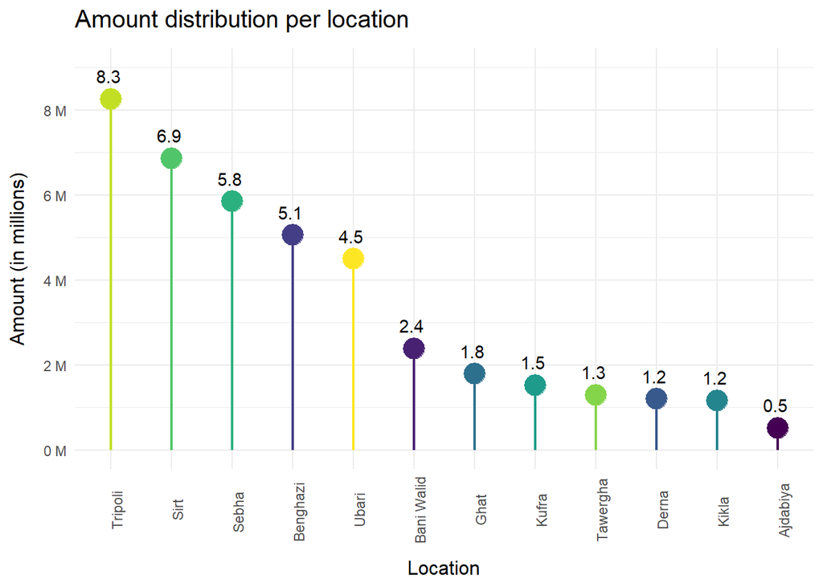

```r
ggplot(sfl, aes(x=fct_reorder(Location, Amount, .fun = sum, .desc = T, .na_rm = T) , y=Amount, fill=Location))+
        geom_col(width = 0.04)+
        stat_summary(aes(color=Location), fun = sum, geom = "point", size = 6) +
        scale_fill_viridis_d(guide=NULL)+
        scale_color_viridis_d(guide=NULL)+
        scale_y_continuous(limits = c(NA,9000000), n.breaks = 6, labels = unit_format(unit="M",scale = 1e-6))+
        stat_summary(fun = sum, geom = "text",
                     aes(label = scales::unit_format(unit = "", scale = 1e-6, accuracy = 0.1)(..y..)),
                     color="black", vjust = -1.2, na.rm = T) +
        labs(title = "Amount distribution per location",
             x="Location",
             y="Amount (in millions)")+
        theme(plot.title = element_text(size=15, margin = margin(b=10)),
              axis.title = element_text(size=12),
              axis.title.y = element_text(margin = margin(r=10)),
              axis.title.x = element_text(margin = margin(t=10)),
              axis.text.x = element_text(angle=90))
```

**Summary:** Here also, Tripoli has the highest value. Along with highest number of activities, it also had other high value activities.